# Trabajos Individuales

Lavezzolo

24/9/2021

# Trabajos individuales:

Los c(*TP1 : TP3) (nerd!)* no tuvieron consignas “formales”. Fueron indicaciones generales con propuestas para ejercitar parte de lo visto hasta ese momento en las clases. Que tengan libertad de elegir temas de su interes o que ya estuvieran trabajando, aplicando las herramientas que estamos aprendiendo. TP1: Consistía en elegir alguna fuente de datos, importarla en un proyecto de R, limpiarlos, transformalos, describirlos TP2: La propuesta original en clase fue que intetaran hacer el scrape de los datos de TC de él cronista. Ayer hablamos de que pudieran entregar como TP un ejercicio análogo para cualquier otra fuente de datos TP3: será avanzar sobre lo anterior con el foco puesto en la entrega de una visualización de datos, siguiendo lo que avancemos las proximas dos semanas.

En esta ejercitación voy a realizar diferentes trabajos que combinan herramientas de los puntos expresados anteriormente.

- Análisis de reviews en Centro de Transbordo Once
- Scrapping Wikipedia Argentina y procesamiento de datos en mapas
- Scrapping el cronista

# 1-Análisis de reviews en Centro de Transbordo Once

Se descargó desde Outscraper los datos de las reviews de Google del centro de Transbordo Once

```r
#Carga de librerias
library(tidyverse)
library(lubridate)
library(tidytext)
library(tokenizers)
library(readxl)
library(viridis)
library(dplyr)
library(conflicted)
conflict_prefer("filter", "dplyr")
conflict_prefer("rename", "dplyr")
conflict_prefer("count", "dplyr")
conflict_prefer("mutate", "dplyr")
conflict_prefer("arrange", "dplyr")
conflict_prefer("summarise", "dplyr")
```

Visualizo los datos en relación al ranking y la cantidad de puntuaciones a lo largo de los años

```r
# Carga de archivos a utilizar
once<- read_xlsx("../Entradas/once_datos.xlsx")

#Edición de los datos a utilizar para fechas
once <- once %>%
  mutate(ano=  substr (review_datetime_utc, start = 7, stop =10)) %>%
  mutate(mes=substr(review_datetime_utc, star=1, stop = 2))

#Reordeno datos
once1 <- once %>%
  select(c("review_rating", "ano", "mes")) %>%
  group_by(ano, review_rating) %>%
  summarise(total = n())
```

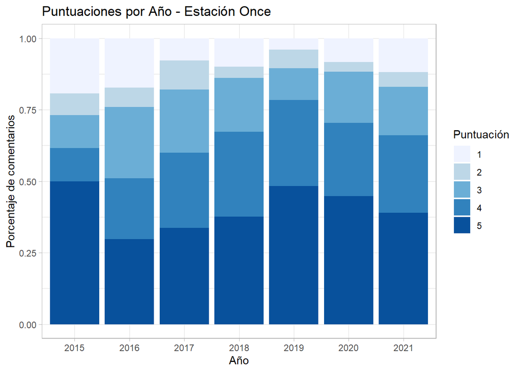

```r
#Grafico

ggplot(once) +
  aes(x = ano, fill = factor(review_rating)) +
  geom_bar(position = "fill") +
  scale_fill_brewer(palette = "Blues")+
  theme_light()+
  labs(title = "Puntuaciones por Año - Estación Once",
       x = "Año",
       y = "Porcentaje de comentarios",
       fill="Puntuación")
```

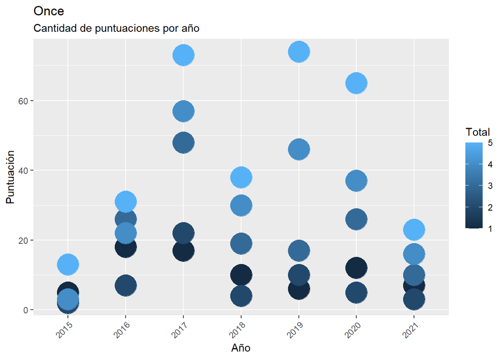

```r
ggplot(once1) +
  geom_point(aes(y=total, x=ano, color =review_rating),
             size=10) +
  scale_fill_brewer(direction=-1,palette = "Blues") +
  theme(axis.text.x = element_text(angle = 45, hjust=1)) +
  labs(title="Once",
       subtitle = "Cantidad de puntuaciones por año",
       x = "Año",
       y = "Puntuación",
       color="Total")
```

Investigo cuáles son las palabras más utilizadas por los usuarios del Centro de Transbordo de Once. Para esto se trabajó dividiendo todas las palabras del comentario. Luego se trabajó con una base de datos de las palabrás más utilizadas en el habla castellana de modo de realizan un “antijoin” y así evitar que aparezcan palabras del tipo “de, a, la”, entre otras.

```r
once_tokenizado <- once %>%
  unnest_tokens(word, review_text)

once_tokenizado <- once_tokenizado %>%

  filter(!is.na(once_tokenizado$word))

head(once_tokenizado)
```

```
## # A tibble: 6 x 23
##   place_name  google_id place_id reviews_link reviews_per_sco~ rating autor_link
##   <chr>       <chr>     <chr>    <chr>        <chr>             <dbl> <chr>
## 1 Estación O~ 0x95bcca~ ChIJacC~ https://sea~ "{\"1\": 75, \"~    3.8 https://w~
## 2 Estación O~ 0x95bcca~ ChIJacC~ https://sea~ "{\"1\": 75, \"~    3.8 https://w~
## 3 Estación O~ 0x95bcca~ ChIJacC~ https://sea~ "{\"1\": 75, \"~    3.8 https://w~
## 4 Estación O~ 0x95bcca~ ChIJacC~ https://sea~ "{\"1\": 75, \"~    3.8 https://w~
## 5 Estación O~ 0x95bcca~ ChIJacC~ https://sea~ "{\"1\": 75, \"~    3.8 https://w~
## 6 Estación O~ 0x95bcca~ ChIJacC~ https://sea~ "{\"1\": 75, \"~    3.8 https://w~
## # ... with 16 more variables: autor_name <chr>, autor_id <chr>,
## #   autor_image <chr>, review_img_url <chr>, owner_answer <lgl>,
## #   owner_answer_timestamp <lgl>, owner_answer_timestamp_datetime_utc <lgl>,
## #   review_link <chr>, review_rating <dbl>, review_timestamp <dbl>,
## #   review_datetime_utc <chr>, review_likes <dbl>, reviews_id <chr>, ano <chr>,
## #   mes <chr>, word <chr>
```

```r
stopwords_es <- read.csv("https://bitsandbricks.github.io/data/stopwords_es.csv",
                         stringsAsFactors = FALSE)



once_tokenizado <- once_tokenizado %>%
  anti_join(stopwords_es, by = c("word" = "STOPWORD"))

toppalabras <- once_tokenizado %>%
  count(word, sort = TRUE) %>%
  head(n=40      )

#Selecciono las palabras
once_resumido <- data.frame(word= c("Seguridad", "Servicio", "Baños", "Linda",
                                    "Limpieza", "Cuidado", "Horarios", "Pico", "Excelente",
                                    "Frecuencia"),
                            n= c(20, 19, 18,18,
                                 13, 16, 13, 11,11,9))
```

```r
library(fmsb)
```

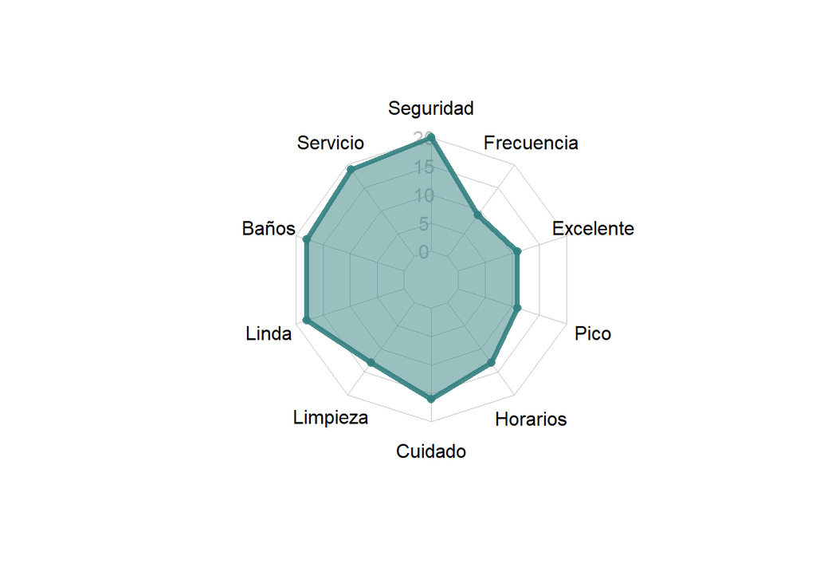

```r
#Grafico
toppalabrasonce_radar <- as.data.frame(matrix( once_resumido$n , ncol=10))
colnames(toppalabrasonce_radar) <- c(once_resumido$word)

toppalabrasonce_radar <-   rbind(rep(20,10) , rep(0,10) ,toppalabrasonce_radar)



radarchart(toppalabrasonce_radar,  axistype=1 ,

           #customizo el polígono
           pcol=rgb(0.2,0.5,0.5,0.9) , pfcol=rgb(0.2,0.5,0.5,0.5) , plwd=4 ,

           #customizo la grilla
           cglcol="grey", cglty=1, axislabcol="grey", caxislabels=seq(0,20,5), cglwd=0.8,

            #customizo los niveles
           vlcex=1 )
```

La graficación de palabras más frecuentes resulta una herramienta útil a la hora de realizar una visualización de las posibles fortalezas y debilidades de cada centro de trasbordo. Asimismo, esta graficación puede utilizarse de manera comparativa entre distintas infraestructuras de transporte entre sí, en distintas instancias temporales o alguna otra variable de interés. Resulta importante indagar de qué manera es utilizada cada palabra, ya que en ciertos casos puede ser tanto positiva como negativa, generando diferencias en los resultados.

Investigo cuáles son las palabras más utilizadas por las personas según el género. Para esto se trabajó con una base de datos de nombres hispanos.

```r
path <- 'https://www.dropbox.com/s/edm5383iffurv4x/nombres.csv?dl=1'
df <- read.csv(path, sep=",",  colClasses = "character")

libs<-c('tm','stringi')
lapply(libs,require, character.only= TRUE)
```

```
## [[1]]
## [1] TRUE
##
## [[2]]
## [1] TRUE
```

```r
# FUNCIONES ------------------------------
clean_txt <- function(txt){
  txt <- stri_trim(gsub('[[:punct:][:digit:] ]+',' ',tolower(txt)))
  return(strsplit(txt, " ")[[1]])
}
get_gender2 <- function(nombre, lista_nombres="") {
  nombre <- clean_txt(nombre)
  nombre <- subset(nombre, nombre %in% lista_nombres)
  mylist <- list()
  mylist[c("f", "m","a")] <- 0
  for (i in 1:length(nombre)){
    g <- as.character(df[which(df$nombre == nombre[i]),"genero"])
    g <- ifelse(identical(g, character(0)), 'a', g)
    if(i==1){
      mylist[[g]] <- mylist[[g]] + 2
    } else{
      mylist[[g]] <- mylist[[g]] + 1
    }
    g2 = sapply(mylist, function(x) x[which.max(abs(x))])
    return(names(g2[g2==max(g2)])[1])
  }
}
# DATOS ---------------------------------
path <- 'https://www.dropbox.com/s/edm5383iffurv4x/nombres.csv?dl=1'
df <- read.csv(path, sep=",",  colClasses = "character")
get_gender2("jose maria altagracia", df$nombre)
```

```
## [1] "m"
```

```r
once_genero <- once_tokenizado

once_genero %>%
  #select(autor_name, autor_id) %>%
  group_by(autor_id) %>%
  nest() %>%
  mutate(genero = map2(data, autor_id,
                       .f =  ~ get_gender2(nombre = .x$autor_name,
                                           lista_nombres = df$nombre))) %>%
  unnest(cols = c(data, genero))
```

```
## # A tibble: 3,555 x 24
## # Groups:   autor_id [381]
##    autor_id  place_name  google_id place_id reviews_link reviews_per_sco~ rating
##    <chr>     <chr>       <chr>     <chr>    <chr>        <chr>             <dbl>
##  1 11709066~ Estación O~ 0x95bcca~ ChIJacC~ https://sea~ "{\"1\": 75, \"~    3.8
##  2 11709066~ Estación O~ 0x95bcca~ ChIJacC~ https://sea~ "{\"1\": 75, \"~    3.8
##  3 11709066~ Estación O~ 0x95bcca~ ChIJacC~ https://sea~ "{\"1\": 75, \"~    3.8
##  4 11709066~ Estación O~ 0x95bcca~ ChIJacC~ https://sea~ "{\"1\": 75, \"~    3.8
##  5 11239714~ Estación O~ 0x95bcca~ ChIJacC~ https://sea~ "{\"1\": 75, \"~    3.8
##  6 11239714~ Estación O~ 0x95bcca~ ChIJacC~ https://sea~ "{\"1\": 75, \"~    3.8
##  7 11239714~ Estación O~ 0x95bcca~ ChIJacC~ https://sea~ "{\"1\": 75, \"~    3.8
##  8 11239714~ Estación O~ 0x95bcca~ ChIJacC~ https://sea~ "{\"1\": 75, \"~    3.8
##  9 11239714~ Estación O~ 0x95bcca~ ChIJacC~ https://sea~ "{\"1\": 75, \"~    3.8
## 10 11727278~ Estación O~ 0x95bcca~ ChIJacC~ https://sea~ "{\"1\": 75, \"~    3.8
## # ... with 3,545 more rows, and 17 more variables: autor_link <chr>,
## #   autor_name <chr>, autor_image <chr>, review_img_url <chr>,
## #   owner_answer <lgl>, owner_answer_timestamp <lgl>,
## #   owner_answer_timestamp_datetime_utc <lgl>, review_link <chr>,
## #   review_rating <dbl>, review_timestamp <dbl>, review_datetime_utc <chr>,
## #   review_likes <dbl>, reviews_id <chr>, ano <chr>, mes <chr>, word <chr>,
## #   genero <chr>
```

```r
once_genero <- once_genero %>%

  group_by(autor_id) %>%
  nest() %>%
  mutate(genero = map2(.x = data,
                       .y = autor_id,
                       .f =  ~ get_gender2(nombre = .x$autor_name,
                                           lista_nombres = df$nombre))) %>%
  unnest(cols = c(data, genero))
```

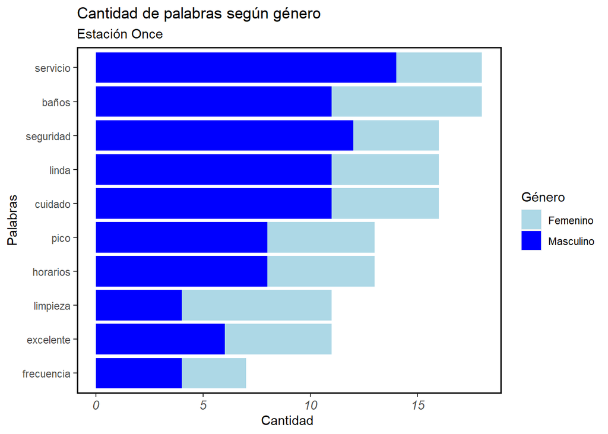

```r
#Reordeno datos
once_f25 <- once_genero %>%
   ungroup() %>%
  count(word, genero,  sort = TRUE) %>%
  data.frame() %>%
  filter(genero == "f"| genero =="m") %>%
  filter(word=="seguridad"| word=="servicio"|word=="baños"|word=="linda" |word=="limpieza"
         |word=="cuidado"|word=="horarios"|word=="pico"|word=="excelente"|word=="frecuencia")

once_f25 [ once_f25  == "f"] <- "Femenino"
once_f25 [ once_f25  == "m"] <- "Masculino"


#Grafico
  ggplot(once_f25) +
    geom_bar(aes(x = reorder(word, n), weight =n, fill=genero))+
    labs(title = "Cantidad de palabras según género",
         subtitle = "Estación Once",
         x = "Palabras",
         y = "Cantidad ",
         fill="Género")+
    scale_fill_manual(values=c("lightblue", "blue"))+
        theme(  axis.text.x = element_text(size = 10, face = "italic"),
            panel.grid = element_blank(),
            panel.background = element_rect(fill = "white", colour = "black", size = 1))+
    coord_flip()
```

Genero nubes de palabras utilizadas

```r
library(wordcloud2)
library(wordcloud)
wordcloud2(data=toppalabras, size=1.6)
```

[interactive chart not shown]

# 2-Scrapping Wikipedia Argentina y procesamiento de datos en mapas

```r
# CARGO PAQUETES
library(rvest) # Easily Harvest (Scrape) Web Pages, CRAN v0.3.6
library(XML) # Tools for Parsing and Generating XML Within R and S-Plus, CRAN v3.99-0.5
library(tidyverse) # Easily Install and Load the 'Tidyverse', CRAN v1.3.0
```

```r
## ARGENTINA ####

argentina <- "https://en.wikipedia.org/wiki/List_of_Argentine_provinces_by_population"


argentina2 <- read_html(argentina) %>%
  html_nodes(xpath = '//*[@id="mw-content-text"]/div[1]/table') %>% # Selector Gadget Copy Xpath
  html_table(fill = T)



argentina3 <- argentina2[[1]] %>%
  rename("Provincia"= "Province/District") %>%
  data.frame()


 argentina3 [ argentina3  == "Autonomous City of Buenos Aires"] <- "Ciudad Autónoma de Buenos Aires"
```

```r
#Es necesario pasar los números que están como chr a numérico
 library(dplyr)
 library(stringr)
 argentina4 <- argentina3 %>%
   mutate_all(list(~ str_replace_all(., ",", "") %>%
                     as.numeric %>%
                     replace_na(0)))
 argentina5 <- argentina4 %>%
   left_join(argentina3, by="Rank") %>%
   ungroup()

 library(plyr)
 argentina5 <- argentina5 %>%
   select(Provincia.y, "Population..2013..2..x") %>%
  rename(Provincia  = Provincia.y) %>%
  rename(Población = "Population..2013..2..x")




 argentina5 <- mutate(argentina5, porcentaje =Población/sum(Población)*100)


 argentina5<- ddply(argentina5, "Provincia", transform,
                               Etiquetas = paste(round(porcentaje, digits=1), '%'))
```

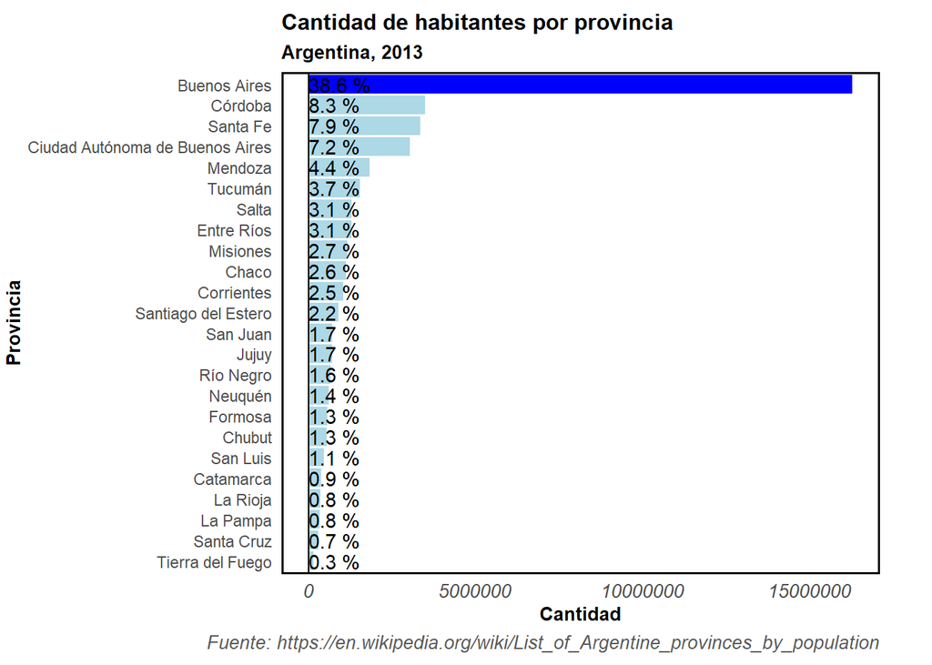

```r
# Elimino la notación  científica

options(scipen=999)

#grafico

 ggplot(argentina5) +
   geom_col(aes(x = reorder(Provincia, Población), y = Población,
                fill = ifelse(Provincia == "Buenos Aires", "A","B"))) +
   geom_hline(yintercept = 0) +
   scale_fill_manual(values=c(A="blue", B="lightblue")) +
   geom_text(aes(x = reorder(Provincia, as.numeric(Etiquetas)),
                 y = as.numeric(porcentaje),
                 label = Etiquetas),
             hjust = "inward") +
   labs(title = "Cantidad de habitantes por provincia",
        subtitle = "Argentina, 2013",
        caption = "Fuente: https://en.wikipedia.org/wiki/List_of_Argentine_provinces_by_population",
        x = "Provincia",
        y = "Cantidad") +
   coord_flip() +
   theme_minimal()+
   theme(plot.margin = margin(0.25, 1, 0.25, 0.1, "cm"),
         plot.caption=element_text(face = "italic", colour = "gray35",size=10),
         title=element_text(size=10, face = "bold"),
         legend.position = "none")+

   theme(  axis.text.x = element_text(size = 10, face = "italic"),
           panel.grid = element_blank(),
           panel.background = element_rect(fill = "white", colour = "black", size = 1))
```

Uno en el mapa para poder visualizar los valores en la región

```r
#Obtengo el mapa
library(geoAr)

 argentina_sf <- get_geo("ARGENTINA")

 library(sf)
 codigos <- show_arg_codes() %>%
   print(n = Inf)
```

```
## # A tibble: 26 x 5
##    id                  codprov codprov_censo codprov_iso name_iso
##    <chr>               <chr>   <chr>         <chr>       <chr>
##  1 ARGENTINA           " "     " "           AR          Argentina
##  2 CABA                "01"    "02"          AR-C        Ciudad Autónoma de Bue~
##  3 BUENOS AIRES        "02"    "06"          AR-B        Buenos Aires
##  4 CATAMARCA           "03"    "10"          AR-K        Catamarca
##  5 CORDOBA             "04"    "14"          AR-X        Córdoba
##  6 CORRIENTES          "05"    "18"          AR-W        Corrientes
##  7 CHACO               "06"    "22"          AR-H        Chaco
##  8 CHUBUT              "07"    "26"          AR-U        Chubut
##  9 ENTRE RIOS          "08"    "30"          AR-E        Entre Ríos
## 10 FORMOSA             "09"    "34"          AR-P        Formosa
## 11 JUJUY               "10"    "38"          AR-Y        Jujuy
## 12 LA PAMPA            "11"    "42"          AR-L        La Pampa
## 13 LA RIOJA            "12"    "46"          AR-F        La Rioja
## 14 MENDOZA             "13"    "50"          AR-M        Mendoza
## 15 MISIONES            "14"    "54"          AR-N        Misiones
## 16 NEUQUEN             "15"    "58"          AR-Q        Neuquén
## 17 RIO NEGRO           "16"    "62"          AR-R        Río Negro
## 18 SALTA               "17"    "66"          AR-A        Salta
## 19 SAN JUAN            "18"    "70"          AR-J        San Juan
## 20 SAN LUIS            "19"    "74"          AR-D        San Luis
## 21 SANTA CRUZ          "20"    "78"          AR-Z        Santa Cruz
## 22 SANTA FE            "21"    "82"          AR-S        Santa Fe
## 23 SANTIAGO DEL ESTERO "22"    "86"          AR-G        Santiago del Estero
## 24 TUCUMAN             "23"    "90"          AR-T        Tucumán
## 25 TIERRA DEL FUEGO    "24"    "94"          AR-V        Tierra del Fuego
## 26 AGLOMERADOS         " "     " "           AR          Aglomerados Urbanos - ~
```

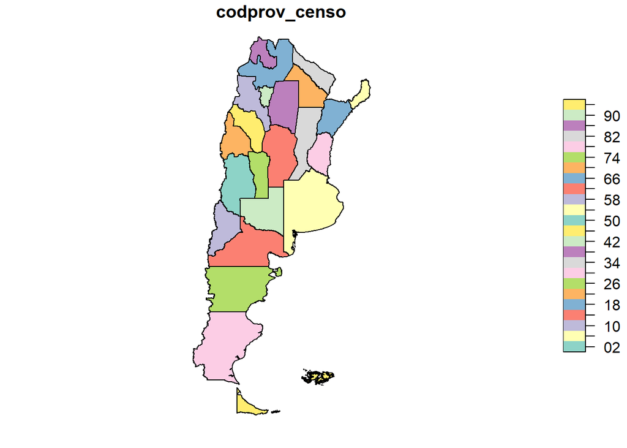

```r
 argentina_sf2 <- get_geo("ARGENTINA",
                       simplified = FALSE)

  # SIMPLIFY GEOMETRY


 library(tidyverse) # Easily Install and Load the 'Tidyverse', CRAN v1.3.0
 library(sf) # Simple Features for R, CRAN v0.9-7
 library(ggplot2) # Create Elegant Data Visualisations Using the Grammar of Graphics, CRAN v3.3.3
 library(rmapshaper) # Client for 'mapshaper' for 'Geospatial' Operations, CRAN v0.4.4
 #### MAP ARGENTINA w/ PROVS ####

 #create a couple temp files

 temp <- tempfile()

 temp2 <- tempfile()

 #download the zip folder from the internet save to 'temp'
 download.file("https://www.indec.gob.ar/ftp/cuadros/territorio/codgeo/Codgeo_Pais_x_prov_datos.zip",temp)
 #unzip the contents in 'temp' and save unzipped content in 'temp2'
 unzip(zipfile = temp, exdir = temp2)
 #finds the filepath of the shapefile (.shp) file in the temp2 unzip folder
 #the $ at the end of ".shp$" ensures you are not also finding files such as .shp.xml
 your_SHP_file<-list.files(temp2, pattern = ".shp$",full.names=TRUE)

 #read the shapefile. Alternatively make an assignment, such as f<-sf::read_sf(your_SHP_file)
 mapa_arg <- sf::read_sf(your_SHP_file) %>%
   select(codprov_censo = link,
          geometry)


 #recorto
 mapa_arg <- mapa_arg %>%
   st_crop(xmin = -78.844299, ymin = -56.918980,
           xmax = -53.531800, ymax = -20.341163)
  plot(mapa_arg)
```

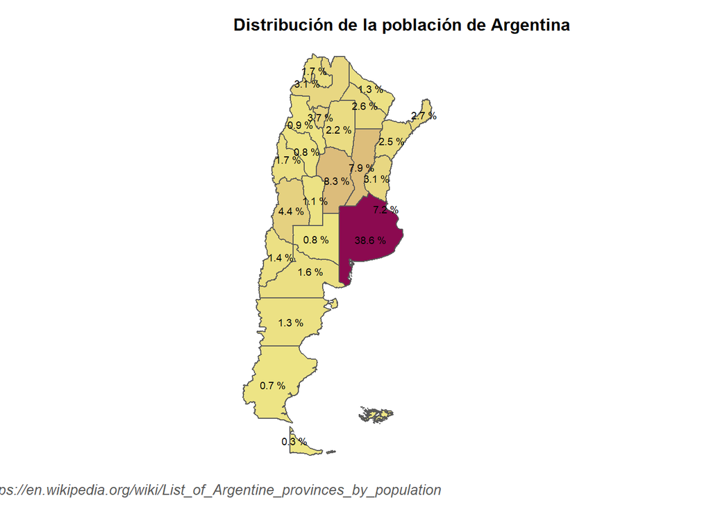

```r
#uno los campos

 mapa_arg_final <- left_join(mapa_arg, codigos, by= "codprov_censo")

 mapa_arg_final <- mapa_arg_final %>%
   rename(Provincia = name_iso)


 mapa_población <- left_join(mapa_arg_final, argentina5, by= "Provincia")

 #Grafico
 ggplot() +
   geom_sf(data =  mapa_población, aes(fill=Población)) +
   geom_sf_text(data=mapa_población, aes(label = Etiquetas), size=2.5, colour = "black")+
   labs(title = "Distribución de la población de Argentina",
                fill = "Cantidad de habitantes por Provincia",
        caption= "Fuente: https://en.wikipedia.org/wiki/List_of_Argentine_provinces_by_population",
        y="",
        x="") +
   scale_fill_gradient(low="khaki2", high="deeppink4")+
   theme_void()+
        theme(plot.margin = margin(0.25, 1, 0.25, 0.1, "cm"),
         plot.caption=element_text(face = "italic", colour = "gray35",size=10),
         title=element_text(size=10, face = "bold"),
         legend.position = "none")
```

# 3-Scrapping el cronista

```r
 url_cronista <- "https://www.cronista.com/MercadosOnline/dolar.html"



moneda <- read_html(url_cronista) %>%
   html_nodes(xpath = '//*[@id="market-scrll-2"]/li/a/span[1]') %>%
   html_text()


compra <- read_html(url_cronista) %>%
  html_nodes(xpath = '//*[@id="market-scrll-2"]/li/a/span[3]/div/div[2]') %>%
  html_text()


venta <- read_html(url_cronista) %>%
  html_nodes(xpath = '//*[@id="market-scrll-2"]/li/a/span[4]/div/div[2]') %>%
  html_text()


variacion <- read_html(url_cronista) %>%
  html_nodes(xpath='//*[@id="market-scrll-2"]/li/a/span[2]/span[2]') %>%
  html_text()



 tabla <- data.frame(moneda, variacion, compra)

 head(tabla)
```

```
##              moneda variacion  compra
## 1         DÓLAR BNA     0,00%  $97,25
## 2        DÓLAR BLUE    -0,54% $178,00
## 3   DÓLAR SOLIDARIO     0,00% $170,36
## 4   DÓLAR MAYORISTA     0,06%  $97,99
## 5   DÓLAR CDO C/LIQ     0,07% $170,71
## 6 DÓLAR MEP Contado     6,27% $171,40
```

el mayor inconveniente se dio que el “dólar solidario”, no tiene precio de compra y el html el valor de venta es la misma columna que los otros de compra.